# Advanced Modeling

Brian A. Fannin

# Continuous vs. Grouped data

Continuous data is fairly easy to model. Integral data which can take many values, e.g. Poisson, may also model well. However, actuaries often work with grouped or categorical data. We can map these to integers, but the numbers convey no meaning.

- State
- Agency
- Line of business

# Quick model

```r
library(ggplot2)
set.seed(1234)
numGroups <- 5
numClaims <- 10
N <- numClaims * numGroups
x <- rnorm(N, 1000, 300)
link <- 1.5

groupVals <- rnorm(numGroups, mean = link, sd = .05 * link)
names(groupVals) <- head(letters, numGroups)
links <- sapply(groupVals, function(x){
  rnorm(numClaims, x, sd = .3 * x)
})

group <- replicate(numClaims, names(groupVals))
group <- as.vector(t(group))

links <- as.vector(links)
df <- data.frame(Group = group
                 , Link = link
                 , SampleLink = links
                 , x = x
                 , stringsAsFactors = FALSE)

df$y <- df$x * df$SampleLink
```

# Look at our data

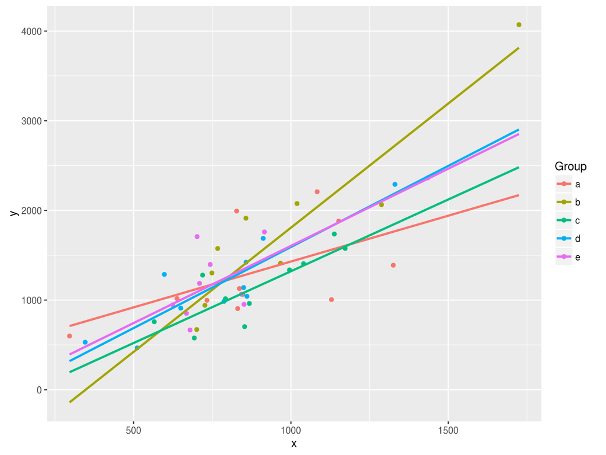

```r
plt <- ggplot(df, aes(x, y, color = Group)) + geom_point()
plt + stat_smooth(method = "lm", fullrange = TRUE, se = FALSE)
```

# Fit our data using `lm`

```r
fit1 <- lm(y ~ x + group, data = df)
summary(fit1)
```

```
##
## Call:
## lm(formula = y ~ x + group, data = df)
##
## Residuals:
##     Min      1Q  Median      3Q     Max
## -758.33 -239.68  -13.36  226.63  955.69
##
## Coefficients:
##              Estimate Std. Error t value Pr(>|t|)
## (Intercept) -325.2061   219.1121  -1.484    0.145
## x              1.8505     0.2083   8.885 2.24e-11 ***
## groupb       249.6776   168.3388   1.483    0.145
## groupc      -174.6100   167.5229  -1.042    0.303
## groupd        76.4751   169.2235   0.452    0.654
## groupe       103.0957   168.1201   0.613    0.543
## ---
## Signif. codes:  0 '***' 0.001 '**' 0.01 '*' 0.05 '.' 0.1 ' ' 1
##
## Residual standard error: 374.6 on 44 degrees of freedom
## Multiple R-squared:  0.6805, Adjusted R-squared:  0.6442
## F-statistic: 18.74 on 5 and 44 DF,  p-value: 6.123e-10
```

Hang on, we don’t want an intercept.

# Remove intercept

```r
fit2 <- lm(y ~ 0 + x + group, data = df)
summary(fit2)
```

```
##
## Call:
## lm(formula = y ~ 0 + x + group, data = df)
##
## Residuals:
##     Min      1Q  Median      3Q     Max
## -758.33 -239.68  -13.36  226.63  955.69
##
## Coefficients:
##         Estimate Std. Error t value Pr(>|t|)
## x         1.8505     0.2083   8.885 2.24e-11 ***
## groupa -325.2061   219.1121  -1.484   0.1449
## groupb  -75.5285   233.2126  -0.324   0.7476
## groupc -499.8162   218.8604  -2.284   0.0273 *
## groupd -248.7310   199.3985  -1.247   0.2188
## groupe -222.1105   207.3405  -1.071   0.2899
## ---
## Signif. codes:  0 '***' 0.001 '**' 0.01 '*' 0.05 '.' 0.1 ' ' 1
##
## Residual standard error: 374.6 on 44 degrees of freedom
## Multiple R-squared:  0.9423, Adjusted R-squared:  0.9345
## F-statistic: 119.8 on 6 and 44 DF,  p-value: < 2.2e-16
```

So, my residuals didn’t change, x didn’t change and those group parameters look an awful lot like intercepts.

# Group data without intercept

```r
fitIndividual <- lm(y ~ 0 + x:group, data = df)
summary(fitIndividual)
```

```
##
## Call:
## lm(formula = y ~ 0 + x:group, data = df)
##
## Residuals:
##     Min      1Q  Median      3Q     Max
## -632.74 -293.95  -10.47  206.94  860.10
##
## Coefficients:
##          Estimate Std. Error t value Pr(>|t|)
## x:groupa   1.4402     0.1231   11.70 3.06e-15 ***
## x:groupb   1.8622     0.1131   16.46  < 2e-16 ***
## x:groupc   1.2988     0.1266   10.26 2.32e-13 ***
## x:groupd   1.5552     0.1411   11.03 2.24e-14 ***
## x:groupe   1.5887     0.1350   11.76 2.53e-15 ***
## ---
## Signif. codes:  0 '***' 0.001 '**' 0.01 '*' 0.05 '.' 0.1 ' ' 1
##
## Residual standard error: 361.8 on 45 degrees of freedom
## Multiple R-squared:  0.945,  Adjusted R-squared:  0.9389
## F-statistic: 154.6 on 5 and 45 DF,  p-value: < 2.2e-16
```

Now, you’re talking!

But wait, I have 50 data points. Am I using all of them for each group?

# One group at a time

```r
lstSplit <- split(df, df$Group)
fits <- lapply(lstSplit, function(z){
  fit <- lm(y ~ 0 + x, data = z)
  fit
})

sapply(fits, coef)
```

```
##      a.x      b.x      c.x      d.x      e.x
## 1.440223 1.862174 1.298766 1.555212 1.588664
```

```r
coef(fitIndividual)
```

```
## x:groupa x:groupb x:groupc x:groupd x:groupe
## 1.440223 1.862174 1.298766 1.555212 1.588664
```

Each group is modelled separately!

# Grouped data is looped data

Using grouped information is like playing a piano. There are no notes between the keys.

Using a hierarchical model is like slide guitar.

# `nlme`

```r
library(nlme)
fitBlended <- lme(data = df, fixed = y ~ 0 + x, random = ~ 0 + x | group)
summary(fitBlended)
```

```
## Linear mixed-effects model fit by REML
##  Data: df
##        AIC      BIC    logLik
##   744.0399 749.7153 -369.0199
##
## Random effects:
##  Formula: ~0 + x | group
##                 x Residual
## StdDev: 0.1776978 361.0706
##
## Fixed effects: y ~ 0 + x
##      Value  Std.Error DF  t-value p-value
## x 1.552723 0.09778386 45 15.87913       0
##
## Standardized Within-Group Residuals:
##        Min         Q1        Med         Q3        Max
## -1.8319725 -0.7932934 -0.1069946  0.5723936  2.8072198
##
## Number of Observations: 50
## Number of Groups: 5
```

```r
unlist(coef(fitBlended))
```

```
##       x1       x2       x3       x4       x5
## 1.476610 1.773171 1.384041 1.554252 1.575540
```

```r
coef(fitIndividual)
```

```
## x:groupa x:groupb x:groupc x:groupd x:groupe
## 1.440223 1.862174 1.298766 1.555212 1.588664
```

```r
sum(df$y - predict(fitBlended))
```

```
## [1] -1007.467
```

```r
sum(df$y - predict(fitIndividual))
```

```
## [1] -905.0304
```

Apparent inferior fit is *by design*. It indicates less than full credibility.

```r
sum(df$y - link * df$x)
```

```
## [1] 1430.774
```

Our **best** predictor would be the global parameter, if we knew what it was. Notice that all of the link ratios in the hierarchical model are closer to 1.5. They will deal better with out of sample data.

# Hierarchical modelling = credibility

Hierarchical modeling allows us to hedge our bets. If the group parameters are close together, we’ll blend all of our experience. If they’re far apart, each group stands on its own.

In the simulation the variance of hypothetical means - the variability between the groups- was less than the expected value of process variance - the variability of the simulated link ratios.

Anyone remember this?

$Z=P/(P+K)$ $K=EVPV/VHM$

EVPV = Expected Value of the process variance

VHM = Variance of the hypothetical means

# Both models with our data

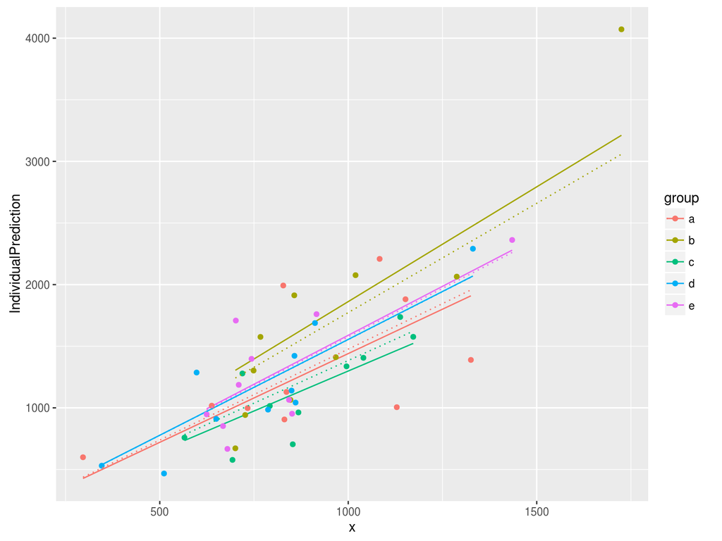

```r
df$IndividualPrediction <- predict(fitIndividual)
df$BlendedPrediction <- predict(fitBlended)

plt <- ggplot(df, aes(x, IndividualPrediction, color = group)) + geom_line() + geom_point(aes(y = y))
plt + geom_line(aes(y = BlendedPrediction), linetype = "dotted")
```

# Pooled data

```r
fitPooled <- lm(y ~ 0 + x, data = df)
summary(fitPooled)
```

```
##
## Call:
## lm(formula = y ~ 0 + x, data = df)
##
## Residuals:
##    Min     1Q Median     3Q    Max
## -758.3 -254.5 -102.2  150.5 1377.2
##
## Coefficients:
##   Estimate Std. Error t value Pr(>|t|)
## x  1.56236    0.06131   25.48   <2e-16 ***
## ---
## Signif. codes:  0 '***' 0.001 '**' 0.01 '*' 0.05 '.' 0.1 ' ' 1
##
## Residual standard error: 391.5 on 49 degrees of freedom
## Multiple R-squared:  0.9298, Adjusted R-squared:  0.9284
## F-statistic: 649.4 on 1 and 49 DF,  p-value: < 2.2e-16
```

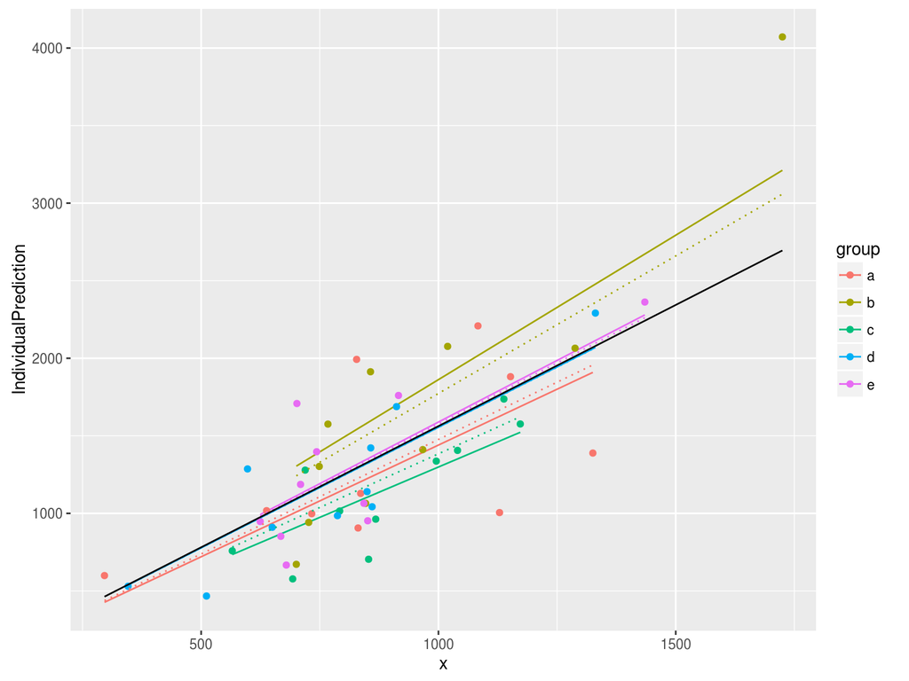

```r
df$PooledPrediction <- predict(fitPooled)
plt <- ggplot(df, aes(x, IndividualPrediction, color = group)) + geom_line() + geom_point(aes(y = y))
plt <- plt + geom_line(aes(y = BlendedPrediction), linetype = "dotted")
plt <- plt + geom_line(aes(y = PooledPrediction), color = "Black")
plt
```